# Praktikum 6 Anreg

Tita Ayu Pramesti

2026-06-25

# Library

```r
library(readxl) # untuk membaca data
library(GGally) # untuk menghasilkan matriks hubungan antarpeubah
library(corrplot) # untuk menghasilkan matriks korelasi
library(dplyr) # untuk manipulasi data
library(car) # untuk memeriksa multikolinearitas
library(stargazer) # untuk menampilkan hasil perbandingan regresi
library(lmtest) # untuk uji kehomogenan ragam sisaan dan saling bebas
library(olsrr) # untuk pemeriksaan amatan tidak biasa
```

# Data

Keterangan peubah yang digunakan:

Y = ASFR (Age-Specific Fertility Rate)

X1 = Persentase penduduk miskin (%)

X2 = Proporsi perempuan umur 20–24 tahun yang berstatus kawin atau hidup bersama sebelum umur 18 tahun (%)

X3 = Angka Partisipasi Sekolah umur 16–18 tahun (%)

X4 = Tingkat Pengangguran Terbuka (TPT) (%)

X5 = Persentase penduduk yang mempunyai keluhan kesehatan (%)

X6 = Cakupan peserta KB aktif (%)

```r
dt <- read_xlsx("C:\\Users\\Tita\\OneDrive\\Documents\\Semester 4\\Anreg\\Data Analisis Regresi.xlsx")
dt # menampilkan data
```

```
## # A tibble: 34 × 9
##       No Provinsi             Y    X1    X2    X3    X4    X5    X6
##    <dbl> <chr>            <dbl> <dbl> <dbl> <dbl> <dbl> <dbl> <dbl>
##  1     1 Aceh              16.4 15.4   5.43  83.3  6.59  34.7  54.3
##  2     2 Sumatera Utara    21.3  9.14  5.95  78.2  6.91  32.2  49.5
##  3     3 Sumatera Barat    14.2  6.56  5.03  83.7  6.88  30.7  58.3
##  4     4 Riau              25.5  7.04  9.19  77.4  6.32  28.3  51.4
##  5     5 Jambi             50.5  7.97 14.0   72.4  5.13  27.4  68.8
##  6     6 Sumatera Selatan  36.5 13.0  13.4   70.9  5.51  33.9  66.5
##  7     7 Bengkulu          38.2 15.3  10.7   79.7  4.07  28.1  71.3
##  8     8 Lampung           34.5 12.8  10.2   71.3  4.67  34.8  68.7
##  9     9 Bangka Belitung   37    4.89 18.8   67.8  5.25  37.7  67.2
## 10    10 Kepulauan Riau    13    6.13  7.31  84.6 10.3   19.3  45.8
## # ℹ 24 more rows
```

```r
str(dt) # menampilkan tipe data setiap peubah
```

```
## tibble [34 × 9] (S3: tbl_df/tbl/data.frame)
##  $ No      : num [1:34] 1 2 3 4 5 6 7 8 9 10 ...
##  $ Provinsi: chr [1:34] "Aceh" "Sumatera Utara" "Sumatera Barat" "Riau" ...
##  $ Y       : num [1:34] 16.4 21.3 14.2 25.5 50.5 36.5 38.2 34.5 37 13 ...
##  $ X1      : num [1:34] 15.43 9.14 6.56 7.04 7.97 ...
##  $ X2      : num [1:34] 5.43 5.95 5.03 9.19 14.03 ...
##  $ X3      : num [1:34] 83.3 78.2 83.7 77.4 72.4 ...
##  $ X4      : num [1:34] 6.59 6.91 6.88 6.32 5.13 ...
##  $ X5      : num [1:34] 34.7 32.2 30.7 28.3 27.4 ...
##  $ X6      : num [1:34] 54.3 49.5 58.3 51.4 68.8 66.5 71.3 68.7 67.2 45.8 ...
```

```r
summary(dt) # menampilkan ringkasan data
```

```
##        No          Provinsi               Y               X1
##  Min.   : 1.00   Length:34          Min.   : 7.90   Min.   : 4.450
##  1st Qu.: 9.25   Class :character   1st Qu.:22.50   1st Qu.: 6.723
##  Median :17.50   Mode  :character   Median :34.20   Median : 9.065
##  Mean   :17.50                      Mean   :32.49   Mean   :10.806
##  3rd Qu.:25.75                      3rd Qu.:42.62   3rd Qu.:13.040
##  Max.   :34.00                      Max.   :63.10   Max.   :26.800
##        X2              X3              X4               X5
##  Min.   : 1.45   Min.   :64.83   Min.   : 3.320   Min.   :11.21
##  1st Qu.: 8.89   1st Qu.:70.33   1st Qu.: 4.580   1st Qu.:24.62
##  Median :11.88   Median :74.31   Median : 5.570   Median :31.43
##  Mean   :11.41   Mean   :74.97   Mean   : 6.034   Mean   :29.52
##  3rd Qu.:14.85   3rd Qu.:79.34   3rd Qu.: 6.853   3rd Qu.:34.57
##  Max.   :18.76   Max.   :88.95   Max.   :10.950   Max.   :46.21
##        X6
##  Min.   :24.90
##  1st Qu.:52.58
##  Median :60.45
##  Mean   :57.53
##  3rd Qu.:66.15
##  Max.   :71.30
```

Data yang digunakan adalah data dari 34 provinsi di Indonesia tahun 2024. Peubah respon yang digunakan adalah Y, sedangkan peubah penjelas terdiri dari enam peubah kuantitatif, yaitu X1, X2, X3, X4, X5, dan X6.

Untuk mempermudah proses komputasi, peubah No dan Provinsi tidak digunakan dalam pemodelan karena hanya berfungsi sebagai identitas wilayah. Oleh karena itu, analisis dilakukan menggunakan Y sebagai peubah respon dan enam peubah penjelas. Seluruh peubah penjelas yang digunakan bersifat kuantitatif sehingga tidak diperlukan pembentukan data terpisah berdasarkan jenis peubah.a.

```r
dt <- select(dt, -Provinsi)
```

# Eksplorasi Data

## Peubah Respon

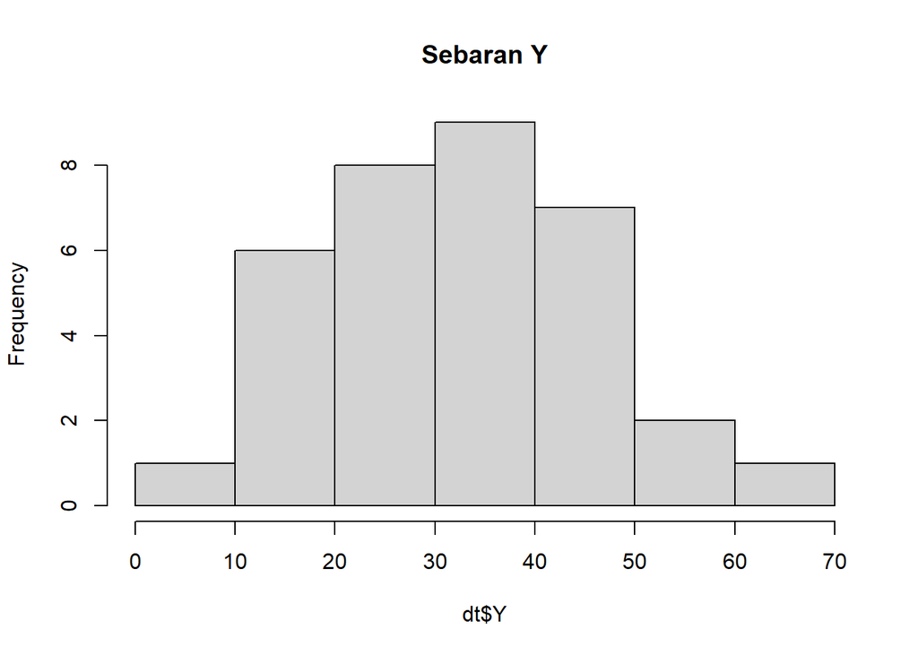

```r
hist(dt$Y, main = "Sebaran Y")
```

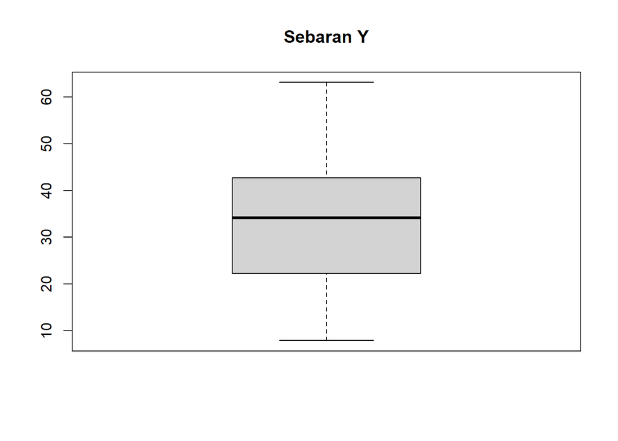

```r
boxplot(dt$Y, main = "Sebaran Y")
```

## Peubah Pennjelas vs Peubah Respon

### X1

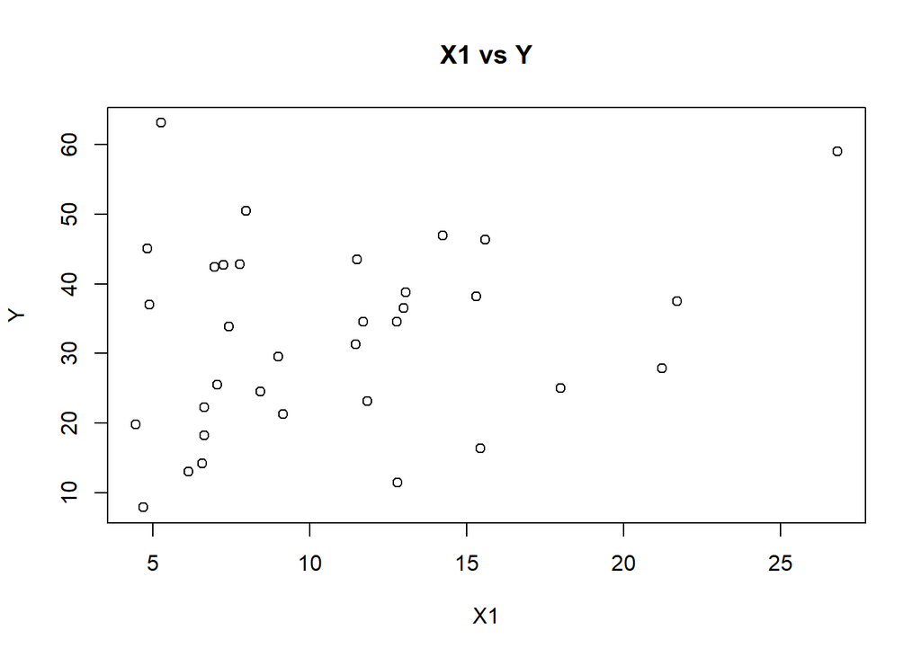

```r
plot(dt$X1, dt$Y, main = "X1 vs Y", xlab = "X1", ylab = "Y")
```

Hubungan antara peubah X1 dan Y cenderung tidak menunjukkan pola linear yang kuat. Selain itu, terdapat satu amatan dengan nilai X1 yang relatif lebih besar dibandingkan amatan lainnya sehingga perlu diperhatikan sebagai kemungkinan pencilan (outlier).

### X2

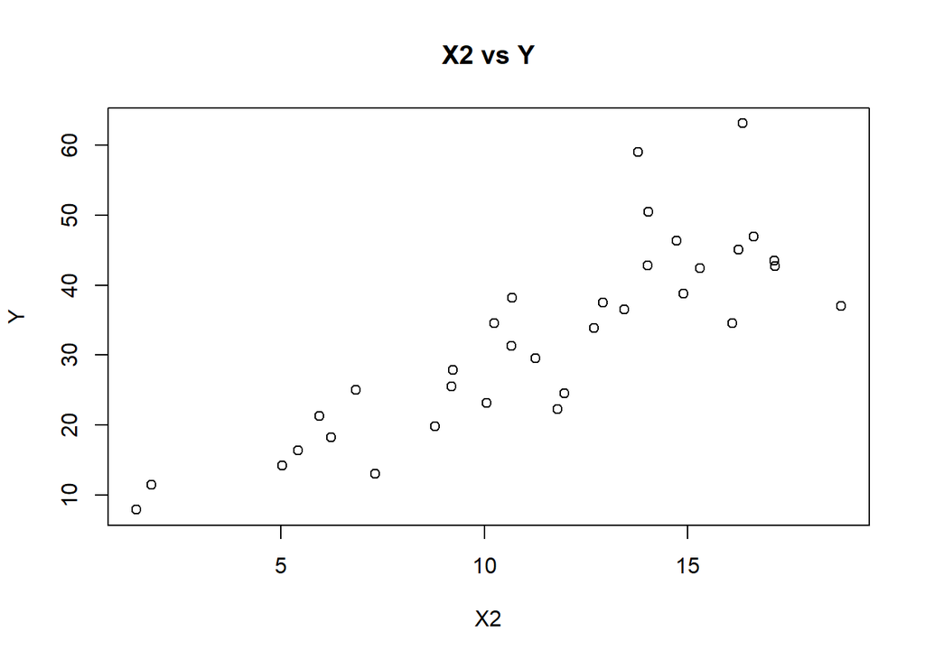

```r
plot(dt$X2, dt$Y, main = "X2 vs Y", xlab = "X2", ylab = "Y")
```

Hubungan antara peubah X2 dan Y cenderung linear positif. Hal ini terlihat dari pola sebaran titik yang membentuk kecenderungan meningkat, yaitu nilai Y cenderung bertambah seiring dengan meningkatnya nilai X2. Selain itu, tidak terlihat adanya pencilan yang ekstrem sehingga asumsi linearitas secara visual cukup terpenuhi.

### X3

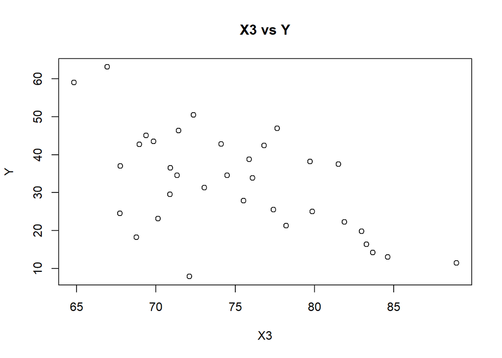

```r
plot(dt$X3, dt$Y, main = "X3 vs Y", xlab = "X3", ylab = "Y")
```

Hubungan antara peubah X3 dan Y cenderung linear negatif. Hal ini terlihat dari pola sebaran titik yang menunjukkan bahwa nilai Y cenderung menurun seiring dengan meningkatnya nilai X3. Selain itu, tidak terlihat adanya amatan yang sangat jauh dari amatan lainnya sehingga tidak terdapat indikasi pencilan yang mencolok.

### X4

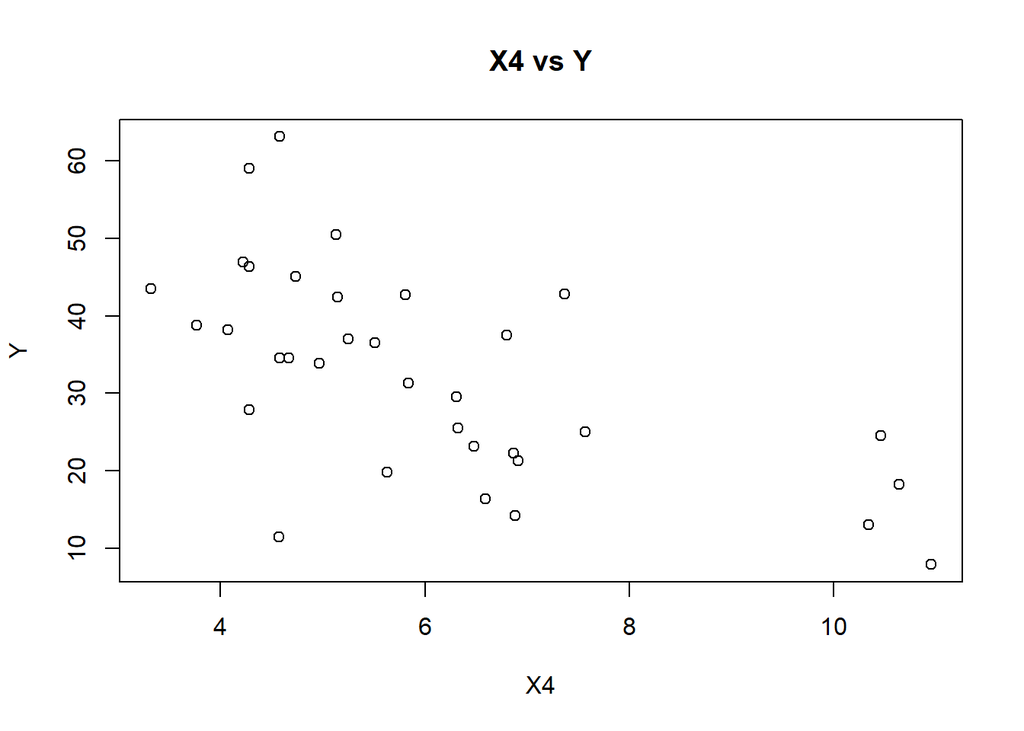

```r
plot(dt$X4, dt$Y, main = "X4 vs Y", xlab = "X4", ylab = "Y")
```

Hubungan antara peubah X4 dan Y cenderung linear negatif. Hal ini terlihat dari pola sebaran titik yang menunjukkan bahwa nilai Y cenderung menurun seiring dengan meningkatnya nilai X4. Selain itu, terdapat beberapa amatan dengan nilai X4 yang relatif lebih besar dibandingkan amatan lainnya, namun masih mengikuti pola hubungan yang terbentuk sehingga tidak menunjukkan adanya pencilan yang mencolok.

### X5

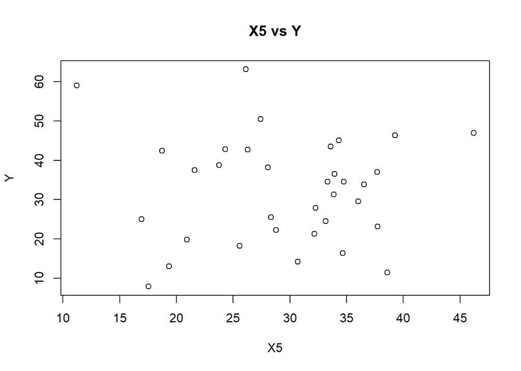

```r
plot(dt$X5, dt$Y, main = "X5 vs Y", xlab = "X5", ylab = "Y")
```

Hubungan antara peubah X5 dan Y cenderung tidak menunjukkan pola linear yang kuat. Sebaran titik relatif acak dan tidak membentuk kecenderungan meningkat maupun menurun secara jelas. Selain itu, tidak terlihat adanya amatan yang jauh dari amatan lainnya sehingga tidak terdapat indikasi pencilan yang mencolok.

### X6

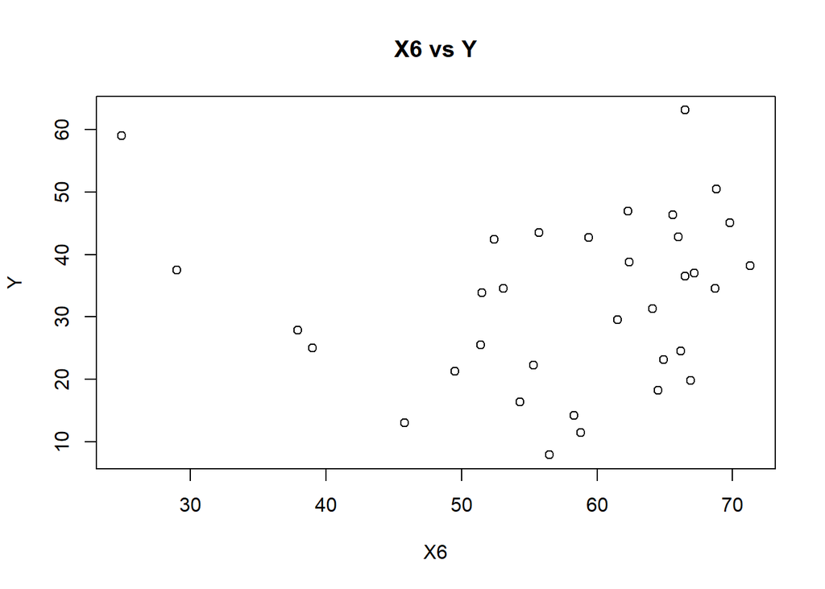

```r
plot(dt$X6, dt$Y, main = "X6 vs Y", xlab = "X6", ylab = "Y")
```

Untuk grafik X6 vs Y, terlihat bahwa sebaran titik cukup acak dan tidak membentuk pola linear yang kuat. Meskipun terdapat kecenderungan hubungan positif yang sangat lemah, hubungan tersebut tidak terlihat jelas dari pola sebaran data. Selain itu, terdapat beberapa amatan dengan nilai X6 yang relatif kecil dibandingkan amatan lainnya, namun tidak tampak sebagai pencilan yang ekstrem.

## Korelasi

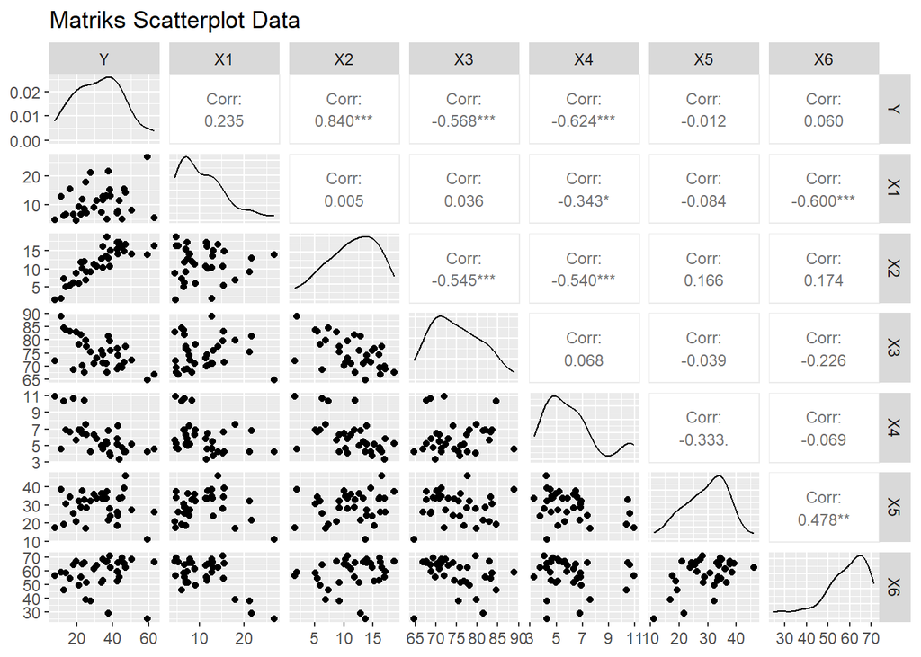

```r
dt <- select(dt, -No)
ggpairs(dt,
        upper = list(continuous = wrap('cor', size = 3)),
        title = "Matriks Scatterplot Data")
```

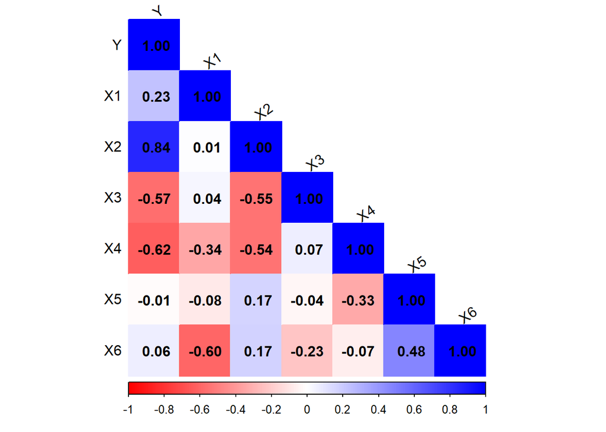

```r
cor_matrix <- cor(dt, use = "complete.obs")

corrplot(cor_matrix, method = "color", type = "lower",
         col = colorRampPalette(c("red", "white", "blue"))(200),
         addCoef.col = "black", tl.col = "black", tl.srt = 35)
```

Hasil matriks scatterplot dan korelasi menunjukkan bahwa peubah respon Y memiliki hubungan positif dengan X1, X2, dan X6, serta hubungan negatif dengan X3, X4, dan X5. Hubungan positif terkuat ditunjukkan oleh X2 dengan koefisien korelasi sebesar 0,84, sedangkan hubungan negatif terkuat ditunjukkan oleh X4 dengan koefisien korelasi sebesar -0,62.

Selain itu, terdapat beberapa korelasi yang cukup tinggi antar peubah penjelas. Beberapa di antaranya adalah korelasi antara X1 dan X6 sebesar -0,60, X2 dan X3 sebesar -0,55, serta X2 dan X4 sebesar -0,54. Namun, seluruh nilai korelasi antar peubah penjelas masih berada di bawah 0,8 sehingga tidak terdapat indikasi multikolinearitas yang kuat berdasarkan matriks korelasi.

# Pemodelan

```r
model1 = lm(formula = Y ~ ., data = dt)
summary(model1)
```

```
##
## Call:
## lm(formula = Y ~ ., data = dt)
##
## Residuals:
##     Min      1Q  Median      3Q     Max
## -8.4239 -3.1396  0.0589  2.5173 14.6126
##
## Coefficients:
##             Estimate Std. Error t value Pr(>|t|)
## (Intercept)  64.4679    26.2511   2.456  0.02078 *
## X1            0.4591     0.2746   1.672  0.10613
## X2            1.7006     0.3410   4.987 3.16e-05 ***
## X3           -0.5104     0.2189  -2.332  0.02741 *
## X4           -2.1379     0.7390  -2.893  0.00745 **
## X5           -0.4660     0.1572  -2.964  0.00628 **
## X6            0.1490     0.1361   1.095  0.28326
## ---
## Signif. codes:  0 '***' 0.001 '**' 0.01 '*' 0.05 '.' 0.1 ' ' 1
##
## Residual standard error: 5.632 on 27 degrees of freedom
## Multiple R-squared:  0.8572, Adjusted R-squared:  0.8254
## F-statistic:    27 on 6 and 27 DF,  p-value: 3.291e-10
```

Persamaan yang terbentuk adalah
$$\hat{Y}=64.4679+0.4591X_1+1.7006X_2-0.5104X_3-2.1379X_4-0.4660X_5+0.1490X_6$$

Pada ringkasan model 1 dapat dilihat bahwa secara simultan terdapat minimal satu peubah penjelas yang berpengaruh signifikan terhadap Y. Hal ini ditunjukkan oleh nilai p-value uji F sebesar 3.291 × 10⁻¹⁰ yang lebih kecil dari 0,05. Secara parsial, peubah X2, X3, X4, dan X5 berpengaruh signifikan terhadap Y pada taraf nyata 5%, sedangkan X1 dan X6 tidak berpengaruh signifikan. Arah koefisien menunjukkan bahwa X1, X2, dan X6 berpengaruh positif terhadap Y, sedangkan X3, X4, dan X5 berpengaruh negatif terhadap Y. Selanjutnya, perlu dilakukan pemeriksaan multikolinearitas dan diagnosis sisaan.

# Pemeriksaan Multikolinearitas

## Perubahan Peubah

```r
mod1 <- lm(Y ~ ., dt[,1:2])
mod2 <- lm(Y ~ ., dt[,1:3])
mod3 <- lm(Y ~ ., dt[,1:4])
mod4 <- lm(Y ~ ., dt[,1:5])
mod5 <- lm(Y ~ ., dt)

stargazer(mod1, mod2, mod3, mod4, mod5,
          type = "text", single.row = TRUE)
```

```
##
## ==================================================================================================================================
##                                                                  Dependent variable:
##                     --------------------------------------------------------------------------------------------------------------
##                                                                           Y
##                            (1)                  (2)                    (3)                    (4)                    (5)
## ----------------------------------------------------------------------------------------------------------------------------------
## X1                    0.585 (0.428)       0.575** (0.219)        0.591*** (0.214)        0.394* (0.221)         0.459 (0.275)
## X2                                        2.521*** (0.265)       2.244*** (0.307)       1.733*** (0.374)       1.701*** (0.341)
## X3                                                                -0.382 (0.232)        -0.548** (0.232)       -0.510** (0.219)
## X4                                                                                      -1.616** (0.746)      -2.138*** (0.739)
## X5                                                                                                            -0.466*** (0.157)
## X6                                                                                                              0.149 (0.136)
## Constant            26.166*** (5.156)      -2.484 (4.004)        29.120 (19.585)       59.300** (23.142)      64.468** (26.251)
## ----------------------------------------------------------------------------------------------------------------------------------
## Observations                34                   34                     34                     34                     34
## R2                        0.055                0.759                  0.779                  0.810                  0.857
## Adjusted R2               0.026                0.744                  0.757                  0.784                  0.825
## Residual Std. Error  13.306 (df = 32)     6.821 (df = 31)        6.641 (df = 30)        6.266 (df = 29)        5.632 (df = 27)
## F Statistic         1.869 (df = 1; 32) 48.936*** (df = 2; 31) 35.329*** (df = 3; 30) 30.933*** (df = 4; 29) 27.003*** (df = 6; 27)
## ==================================================================================================================================
## Note:                                                                                                  *p<0.1; **p<0.05; ***p<0.01
```

Berdasarkan hasil pemodelan bertahap, tanda dan besaran koefisien regresi relatif konsisten ketika peubah penjelas ditambahkan ke dalam model. Selain itu, tidak terlihat perubahan koefisien yang sangat besar antar model. Hal ini menunjukkan bahwa model tidak mengalami masalah multikolinearitas yang serius dan hasil pendugaan parameter cukup stabil.

## Perubahan Banyak Data

```r
mod5_1 <- lm(Y ~ ., dt[1:15,])

stargazer(summary(mod5)$coefficients,
          summary(mod5_1)$coefficients,
          type = "text",
          font.size = "small")
```

```
##
## ===================================================
##             Estimate Std. Error t value Pr(> | t| )
## ---------------------------------------------------
## (Intercept)  64.468    26.251    2.456     0.021
## X1           0.459     0.275     1.672     0.106
## X2           1.701     0.341     4.987    0.00003
## X3           -0.510    0.219    -2.332     0.027
## X4           -2.138    0.739    -2.893     0.007
## X5           -0.466    0.157    -2.964     0.006
## X6           0.149     0.136     1.095     0.283
## ---------------------------------------------------
##
## ===================================================
##             Estimate Std. Error t value Pr(> | t| )
## ---------------------------------------------------
## (Intercept)  71.068    42.831    1.659     0.136
## X1           0.442     0.451     0.980     0.356
## X2           1.569     0.412     3.811     0.005
## X3           -0.365    0.324    -1.129     0.291
## X4           -2.937    0.919    -3.197     0.013
## X5           -0.791    0.254    -3.119     0.014
## X6           0.134     0.258     0.518     0.618
## ---------------------------------------------------
```

Hasil perbandingan menunjukkan bahwa koefisien regresi mengalami perubahan nilai ketika jumlah amatan dikurangi dari 34 menjadi 15 observasi. Namun, seluruh koefisien tetap memiliki arah pengaruh yang sama sehingga model masih menunjukkan kestabilan yang cukup baik. Perubahan nilai koefisien ini mengindikasikan bahwa jumlah amatan dapat memengaruhi ketepatan pendugaan parameter, tetapi tidak menunjukkan adanya permasalahan yang serius pada model.

## Akar Ciri

```r
x <- dt[-1]
r <- cor(x)
(ev <- eigen(r)$values)
```

```
## [1] 2.1028752 1.6952139 1.1460496 0.5761701 0.3121171 0.1675741
```

```r
# Simultan
if ((max(ev) / min(ev)) <= 100) {
  cat("Tidak ada multikolinearitas\n")
} else if ((max(ev) / min(ev)) > 100 & (max(ev) / min(ev)) <= 1000) {
  cat("Ada multikolinearitas yang lemah\n")
} else {
  cat("Ada multikolinearitas yang kuat\n")
}
```

```
## Tidak ada multikolinearitas
```

```r
# Parsial
if (all((max(ev) / ev) <= 1000)) {
  cat("Tidak ada multikolinearitas\n")
} else {
  cat("Ada multikolinearitas pada peubah penjelas ke:", which((max(ev) / ev) > 1000), "\n")
}
```

```
## Tidak ada multikolinearitas
```

## Nilai VIF

```r
vif(model1)
```

```
##       X1       X2       X3       X4       X5       X6
## 2.298180 2.436711 1.765969 2.301936 1.525323 2.516912
```

Hasil pemeriksaan akar ciri menunjukkan bahwa model tidak mengalami masalah multikolinearitas. Hal ini ditunjukkan oleh nilai rasio akar ciri maksimum terhadap minimum yang masih berada di bawah 100. Hasil pemeriksaan parsial juga menunjukkan tidak ada peubah penjelas yang memiliki indikasi multikolinearitas kuat. Selain itu, nilai VIF seluruh peubah penjelas berada di bawah 10, dengan nilai VIF tertinggi sebesar 2,5169 pada X6. Dengan demikian, model regresi yang terbentuk tidak mengalami masalah multikolinearitas yang serius sehingga tidak perlu dilakukan penghapusan peubah.

# Pengujian Asumsi

## Eksplorasi Grafik

### Plot Sisaan vs Y duga

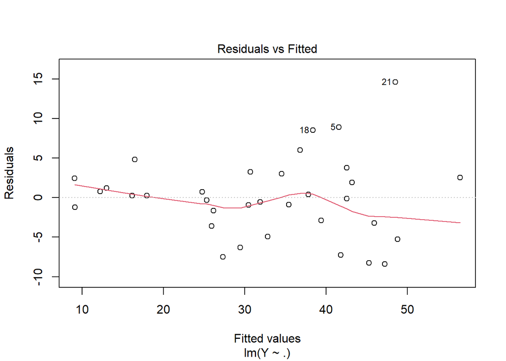

```r
plot(model1,1)
```

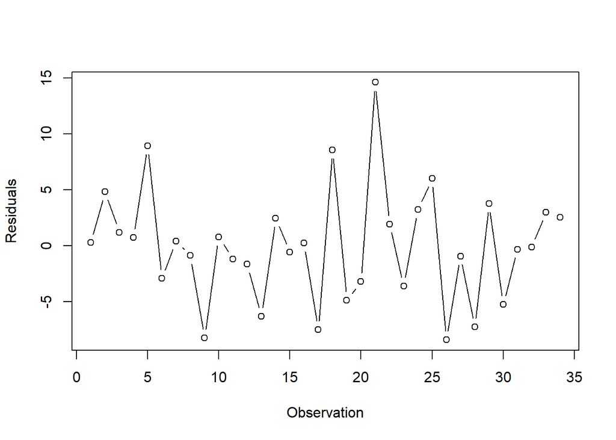

```r
plot(x = 1:dim(dt)[1],
     y = model1$residuals,
     type = 'b',
     ylab = "Residuals",
     xlab = "Observation")
```

Berdasarkan grafik sisaan terhadap urutan pengamatan, titik-titik sisaan tersebar secara acak di sekitar garis nol dan tidak menunjukkan pola tertentu yang sistematis, seperti tren meningkat, tren menurun, maupun pola gelombang yang berulang. Hal ini menunjukkan bahwa asumsi kebebasan sisaan (independence of errors) secara visual cukup terpenuhi. Meskipun terdapat beberapa amatan dengan nilai sisaan yang relatif besar, tidak terlihat adanya pola yang mengindikasikan autokorelasi.

### QQ plot

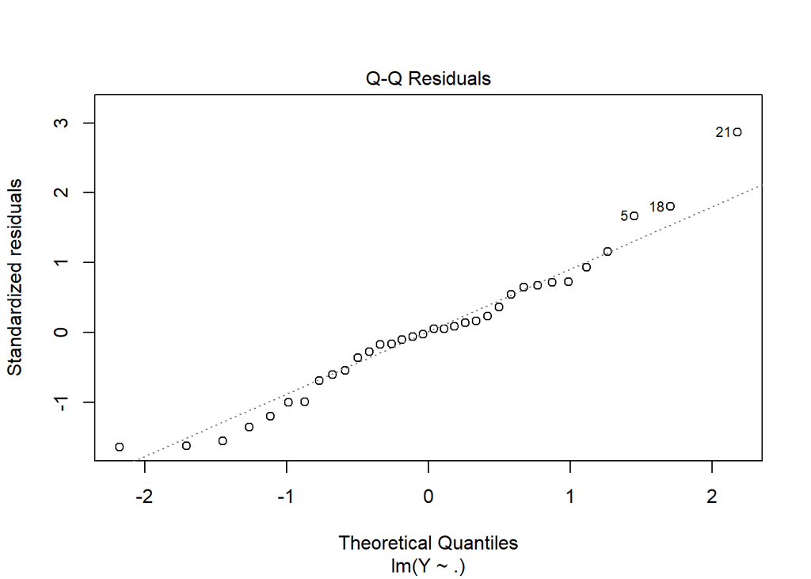

```r
plot(model1,2)
```

Berdasarkan grafik Normal Q-Q Plot, sebagian besar titik sisaan berada di sekitar garis diagonal. Hal ini menunjukkan bahwa distribusi sisaan cenderung mengikuti distribusi normal. Meskipun terdapat beberapa amatan pada bagian ekor kanan yang sedikit menyimpang dari garis diagonal, penyimpangan tersebut tidak terlalu besar sehingga asumsi normalitas sisaan secara visual dapat dianggap terpenuhi.

## Uji Formal

### Nilai harapan sisaan sama dengan nol

```r
t.test(model1$residuals,mu = 0,conf.level = 0.95)
```

```
##
##  One Sample t-test
##
## data:  model1$residuals
## t = 8.4057e-17, df = 33, p-value = 1
## alternative hypothesis: true mean is not equal to 0
## 95 percent confidence interval:
##  -1.777655  1.777655
## sample estimates:
##    mean of x
## 7.344513e-17
```

Berdasarkan hasil uji One Sample t-test, diperoleh nilai p-value sebesar 1 yang lebih besar dari taraf signifikansi 5%. Oleh karena itu, gagal menolak H₀ sehingga tidak terdapat bukti bahwa rata-rata sisaan berbeda dari nol. Dengan demikian, asumsi nilai harapan sisaan sama dengan nol dapat dianggap terpenuhi.

### Ragam sisaan homogen

```r
bptest(model1)
```

```
##
##  studentized Breusch-Pagan test
##
## data:  model1
## BP = 9.6323, df = 6, p-value = 0.141
```

Berdasarkan hasil uji Breusch-Pagan, diperoleh nilai p-value sebesar 0,141 yang lebih besar dari taraf signifikansi 5%. Oleh karena itu, gagal menolak H₀ sehingga tidak terdapat bukti adanya heteroskedastisitas. Dengan demikian, asumsi ragam sisaan homogen dapat dianggap terpenuhi.

### Sisaan saling bebas

```r
dwtest(model1)
```

```
##
##  Durbin-Watson test
##
## data:  model1
## DW = 2.4627, p-value = 0.8717
## alternative hypothesis: true autocorrelation is greater than 0
```

Berdasarkan hasil uji Durbin-Watson, diperoleh nilai p-value sebesar 0,8717 yang lebih besar dari taraf signifikansi 5%. Oleh karena itu, gagal menolak H₀ sehingga tidak terdapat bukti adanya autokorelasi pada sisaan. Selain itu, nilai statistik Durbin-Watson sebesar 2,4627 yang mendekati 2 juga menunjukkan bahwa sisaan cenderung saling bebas. Dengan demikian, asumsi independensi sisaan dapat dianggap terpenuhi.

### Normalitas Sisaan

```r
shapiro.test(model1$residuals)
```

```
##
##  Shapiro-Wilk normality test
##
## data:  model1$residuals
## W = 0.96134, p-value = 0.2659
```

Berdasarkan hasil uji Shapiro-Wilk, diperoleh nilai p-value sebesar 0,2659 yang lebih besar dari taraf signifikansi 5%. Oleh karena itu, gagal menolak H₀ sehingga tidak terdapat bukti bahwa sisaan menyimpang dari distribusi normal. Dengan demikian, asumsi normalitas sisaan dapat dianggap terpenuhi.

# Pemeriksaan Amatan Tidak Biasa

```r
#fungsi
ri_stud <- rstudent(model1)
ri_stan <- rstandard(model1)
hii_fungsi <- hatvalues(model1)

#manual
X <- model.matrix(model1)
X_inv_xt <- X %*% solve(t(X) %*% X) %*% t(X)
hii_manual <- diag(X_inv_xt)
anova_model <- anova(model1)
s <- sqrt(anova_model["Residuals", "Mean Sq"])
ei <- model1$residuals
ri_manual <- ei/(s*sqrt(1-hii_manual))

nilai <- data.frame(ri_stud, ri_stan, ri_manual, hii_fungsi, hii_manual)
nilai
```

```
##        ri_stud     ri_stan   ri_manual hii_fungsi hii_manual
## 1   0.04971819  0.05066288  0.05066288 0.15899561 0.15899561
## 2   0.93131045  0.93360685  0.93360685 0.15989528 0.15989528
## 3   0.22613366  0.23021508  0.23021508 0.14425903 0.14425903
## 4   0.13729462  0.13985930  0.13985930 0.11739656 0.11739656
## 5   1.72931014  1.66888655  1.66888655 0.09696829 0.09696829
## 6  -0.53476070 -0.54197514 -0.54197514 0.09447544 0.09447544
## 7   0.08282650  0.08439315  0.08439315 0.33233294 0.33233294
## 8  -0.16641607 -0.16949594 -0.16949594 0.14433485 0.14433485
## 9  -1.67603316 -1.62255617 -1.62255617 0.18223970 0.18223970
## 10  0.16238948  0.16539903  0.16539903 0.31984399 0.31984399
## 11 -0.26882629 -0.27356732 -0.27356732 0.37716901 0.37716901
## 12 -0.36000108 -0.36594793 -0.36594793 0.35848205 0.35848205
## 13 -1.21087426 -1.20055348 -1.20055348 0.12555027 0.12555027
## 14  0.53493930  0.54215418  0.54215418 0.36600425 0.36600425
```

[output cut: 20 more lines]

## Pencilan

```r
for (i in 1:dim(nilai)[1]){
  absri <- abs(nilai[,2])
  pencilan <- which(absri > 2)
}
pencilan
```

```
## [1] 21
```

Amatan ke-21 terdeteksi sebagai pencilan

## Leverage

```r
n <- dim(dt)[1]
p <- length(model1$coefficients)

for (i in 1:dim(nilai)[1]){
  cutoff <- 2*p/n
  titik_leverage <- which(hii_fungsi > cutoff)
}
titik_leverage
```

```
## 34
## 34
```

Amatan ke-34 terdeteksi sebagai titik leverage

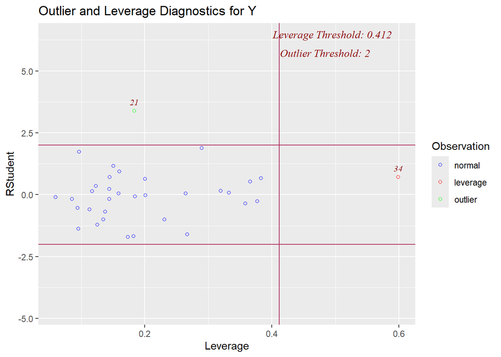

```r
ols_plot_resid_lev(model1)
```

Plot yang terbentuk dari fungsi ‘ols_plot_resid_lev()’ menunjukkan bahwa terdapat satu amatan yang teridentifikasi sebagai pencilan (outlier), yaitu amatan ke-21 karena memiliki nilai studentized residual melebihi batas 2. Selain itu, terdapat satu amatan yang memiliki nilai leverage tinggi, yaitu amatan ke-34 karena nilai leverage-nya melebihi batas 0,412. Namun, tidak terdapat amatan yang secara bersamaan merupakan pencilan dan memiliki leverage tinggi. Oleh karena itu, kedua amatan tersebut perlu diperhatikan lebih lanjut karena berpotensi memengaruhi hasil pendugaan model regresi.

## Amatan Berpengaruh

### Jarak Cook

```r
di <- cooks.distance(model1)
f <- qf(0.05,p,n-p, lower.tail = F)
data.frame(di, di>f)
```

```
##              di di...f
## 1  6.932161e-05  FALSE
## 2  2.369912e-02  FALSE
## 3  1.276351e-03  FALSE
## 4  3.716845e-04  FALSE
## 5  4.272502e-02  FALSE
## 6  4.378037e-03  FALSE
## 7  5.064421e-04  FALSE
## 8  6.922898e-04  FALSE
## 9  8.381435e-02  FALSE
## 10 1.837797e-03  FALSE
## 11 6.474350e-03  FALSE
## 12 1.069053e-02  FALSE
## 13 2.956295e-02  FALSE
## 14 2.424082e-02  FALSE
```

[output cut: 20 more lines]

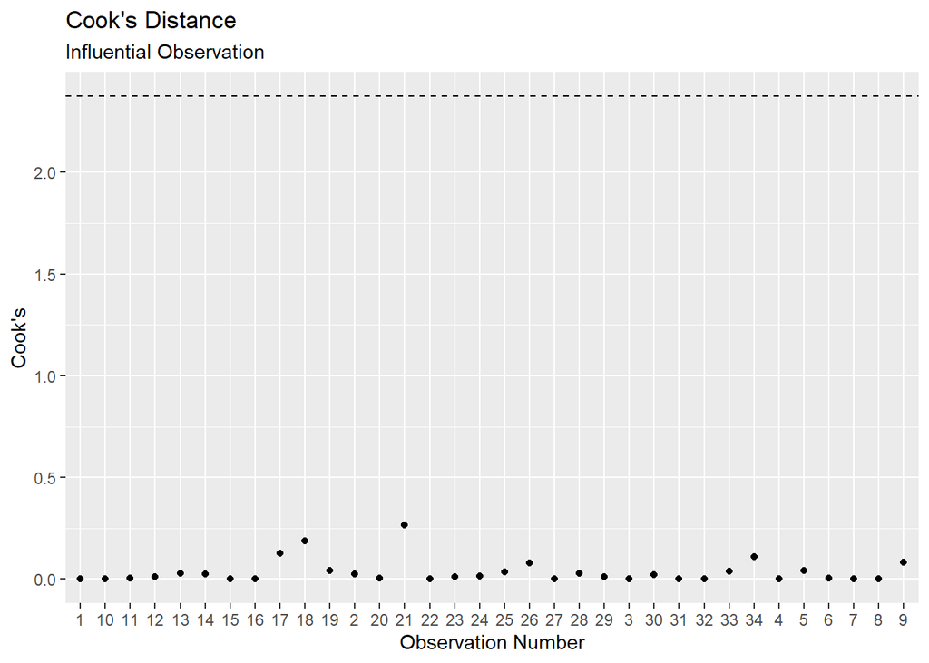

```r
cooks_crit = f
model_cooks <- cooks.distance(model1)
df <- data.frame(obs = names(model_cooks),
                 cooks = model_cooks)
ggplot(df, aes(y = cooks, x = obs)) +
  geom_point() +
  geom_hline(yintercept = cooks_crit, linetype="dashed") +
  labs(title = "Cook's Distance",
       subtitle = "Influential Observation ",
       x = "Observation Number",
       y = "Cook's")
```

Berdasarkan grafik Cook’s Distance, tidak terdapat amatan yang memiliki nilai Cook’s Distance melebihi ambang batas. Hal ini menunjukkan bahwa tidak terdapat amatan yang berpengaruh kuat (influential observation) terhadap model regresi. Meskipun terdapat beberapa amatan dengan nilai Cook’s Distance relatif lebih besar dibandingkan amatan lainnya, nilainya masih berada di bawah batas yang ditentukan sehingga pengaruhnya terhadap pendugaan parameter model tidak signifikan.

### DFBETAS

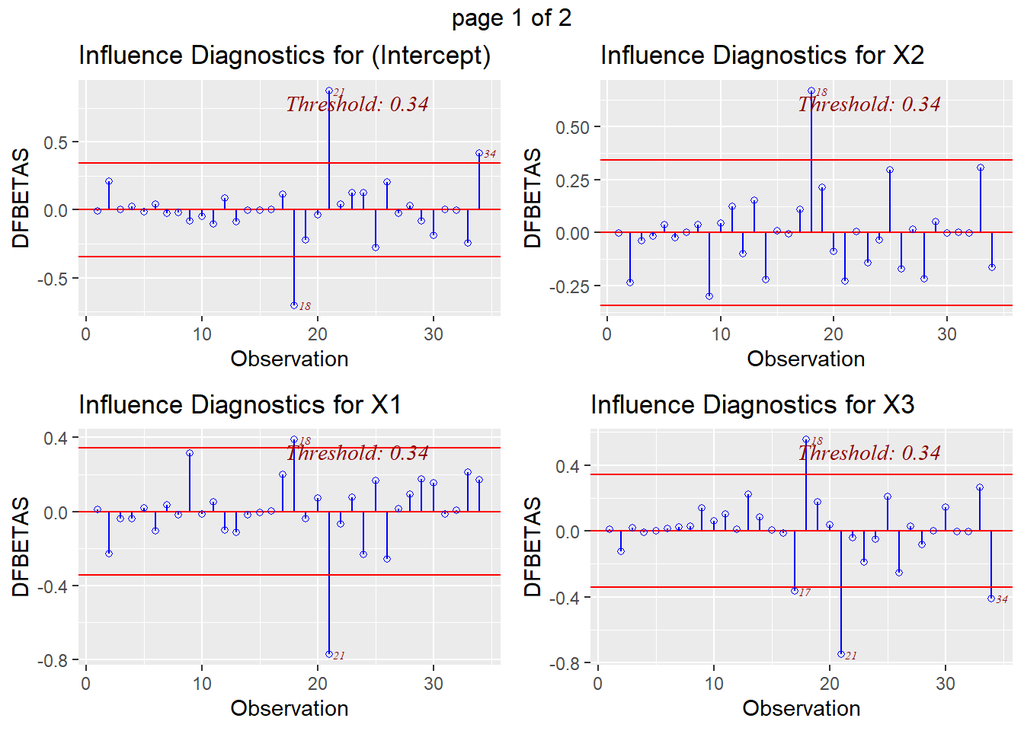

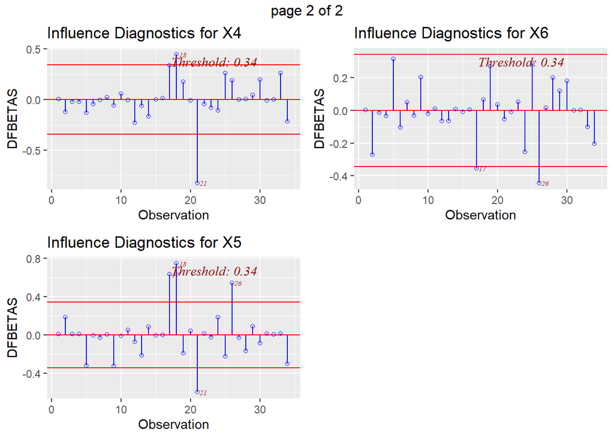

```r
ols_plot_dfbetas(model1)
```

Berdasarkan grafik DFBETAS, terdapat beberapa observasi yang memiliki nilai DFBETAS melebihi ambang batas ±0,34. Observasi yang paling menonjol adalah observasi ke-21, yang memengaruhi beberapa koefisien regresi secara bersamaan. Selain itu, observasi ke-18 dan ke-34 juga menunjukkan pengaruh terhadap beberapa parameter model. Hal ini mengindikasikan bahwa observasi-observasi tersebut memiliki kontribusi yang relatif besar terhadap pendugaan koefisien regresi sehingga perlu mendapat perhatian lebih lanjut.

### DFFITS

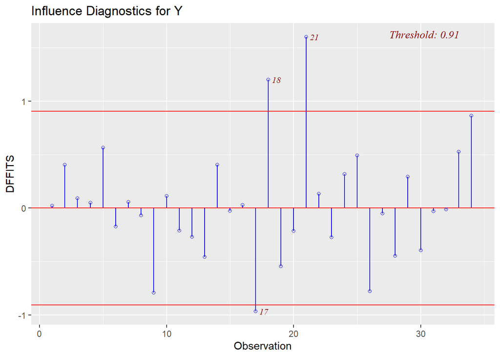

```r
ols_plot_dffits(model1)
```

Berdasarkan grafik DFFITS, terdapat beberapa observasi yang memiliki nilai DFFITS melebihi ambang batas ±0,91, yaitu observasi ke-17, ke-18, dan ke-21. Hal ini menunjukkan bahwa ketiga observasi tersebut memiliki pengaruh yang relatif besar terhadap nilai prediksi respon Y. Di antara ketiganya, observasi ke-21 memiliki nilai DFFITS terbesar sehingga merupakan observasi yang paling berpengaruh terhadap hasil prediksi model. Oleh karena itu, observasi ke-17, ke-18, dan ke-21 perlu mendapat perhatian lebih lanjut dalam proses diagnosis model.

```r
DFFITSi <- dffits(model1)

amatan_berpengaruh <- vector("list", dim(nilai)[1])
for (i in 1:dim(nilai)[1]) {
  cutoff <- 2 * sqrt((p / n))
  amatan_berpengaruh[[i]] <- which(abs(DFFITSi) > cutoff)
}
berpengaruh <- unlist(amatan_berpengaruh)
amatan_berpengaruh <- sort(unique(berpengaruh))
amatan_berpengaruh
```

```
## [1] 17 18 21
```

Berdasarkan nilai DFFITS, observasi ke-17, ke-18, dan ke-21 teridentifikasi sebagai amatan berpengaruh karena memiliki nilai DFFITS yang melebihi ambang batas yang ditentukan. Hal ini menunjukkan bahwa ketiga observasi tersebut memberikan pengaruh yang relatif besar terhadap nilai prediksi model. Oleh karena itu, observasi ke-17, ke-18, dan ke-21 perlu mendapat perhatian lebih lanjut dalam proses diagnosis model.

# Pemodelan Penyisihan Amatan

```r
# Pemodelan Penyisihan Amatan

dt1 <- dt %>% slice(-17)
model3 <- lm(Y ~ X1 + X2 + X3 + X4 + X5 + X6, data = dt1)

dt2 <- dt %>% slice(-18)
model4 <- lm(Y ~ X1 + X2 + X3 + X4 + X5 + X6, data = dt2)

dt3 <- dt %>% slice(-21)
model5 <- lm(Y ~ X1 + X2 + X3 + X4 + X5 + X6, data = dt3)

dt4 <- dt %>% slice(-c(17, 18))
model6 <- lm(Y ~ X1 + X2 + X3 + X4 + X5 + X6, data = dt4)

dt5 <- dt %>% slice(-c(17, 21))
model7 <- lm(Y ~ X1 + X2 + X3 + X4 + X5 + X6, data = dt5)

dt6 <- dt %>% slice(-c(18, 21))
model8 <- lm(Y ~ X1 + X2 + X3 + X4 + X5 + X6, data = dt6)

dt7 <- dt %>% slice(-c(17, 18, 21))
model9 <- lm(Y ~ X1 + X2 + X3 + X4 + X5 + X6, data = dt7)
```

```r
get_metrics <- function(model) {
  adj_r2 <- summary(model)$adj.r.squared
  sse <- sum(model$residuals^2)
  return(c(adj_r2, sse))
}

model_metrics <- data.frame(
  Model = c("Model 1", "Model 3", "Model 4", "Model 5",
            "Model 6", "Model 7", "Model 8", "Model 9"),
  Adjusted_R2 = sapply(
    list(model1, model3, model4, model5,
         model6, model7, model8, model9),
    function(m) get_metrics(m)[1]
  ),
  SSE = sapply(
    list(model1, model3, model4, model5,
         model6, model7, model8, model9),
    function(m) get_metrics(m)[2]
  )
)

print(model_metrics)
```

```
##     Model Adjusted_R2      SSE
## 1 Model 1   0.8254155 856.5762
## 2 Model 3   0.8353941 779.8253
## 3 Model 4   0.8395915 753.6682
## 4 Model 5   0.8544496 594.9882
## 5 Model 6   0.8556792 655.0177
## 6 Model 7   0.8614095 546.3778
## 7 Model 8   0.8655856 519.0724
## 8 Model 9   0.8782341 453.6683
```

Berdasarkan hasil perbandingan model, Model 9 memiliki nilai Adjusted R² tertinggi sebesar 0,8782 dan nilai SSE terendah sebesar 453,6683. Model 9 merupakan model yang menyisihkan amatan ke-17, ke-18, dan ke-21. Dengan demikian, penyisihan ketiga amatan tersebut menghasilkan model dengan kemampuan penjelasan yang lebih baik dan galat yang lebih kecil dibandingkan model lainnya.

```r
stargazer(model1, model9,
          type = "text",
          font.size = "small",
          report = "vc*p")
```

```
##
## =================================================================
##                                  Dependent variable:
##                     ---------------------------------------------
##                                           Y
##                              (1)                    (2)
## -----------------------------------------------------------------
## X1                          0.459                 0.471**
##                           p = 0.107              p = 0.048
##
## X2                         1.701***               1.517***
##                          p = 0.00004            p = 0.00002
##
## X3                         -0.510**               -0.425**
##                           p = 0.028              p = 0.030
##
## X4                        -2.138***              -2.211***
##                           p = 0.008              p = 0.002
##
## X5                        -0.466***              -0.593***
##                           p = 0.007              p = 0.0005
##
## X6                          0.149                  0.190*
##                           p = 0.284              p = 0.090
##
## Constant                   64.468**               61.313**
##                           p = 0.021              p = 0.012
##
## -----------------------------------------------------------------
## Observations                  34                     31
## R2                          0.857                  0.903
## Adjusted R2                 0.825                  0.878
## Residual Std. Error    5.632 (df = 27)        4.348 (df = 24)
## F Statistic         27.003*** (df = 6; 27) 37.062*** (df = 6; 24)
## =================================================================
## Note:                                 *p<0.1; **p<0.05; ***p<0.01
```

Berdasarkan perbandingan Model 1 dan Model 9, penyisihan amatan ke-17, ke-18, dan ke-21 menghasilkan peningkatan kualitas model. Hal ini terlihat dari meningkatnya nilai Adjusted R² dari 0,825 menjadi 0,878 serta menurunnya nilai Residual Standard Error dari 5,632 menjadi 4,348. Selain itu, arah pengaruh seluruh peubah penjelas tetap konsisten setelah penyisihan amatan dilakukan. Oleh karena itu, Model 9 dipilih sebagai model yang lebih baik untuk digunakan dalam analisis karena memiliki kemampuan penjelasan yang lebih tinggi dan galat yang lebih kecil dibandingkan Model 1.